# Configuration Models of Random Hypergraphs

Phil Chodrow, *Massachusetts Institute of Technology

Statistical Inference for Network Models, NetSci 2019 May 27th, 2019

# Introduction

## Polyadic Networks

- **Collaboration** (author/paper, sponsor/bill)
- **Communication** (receiver/email, participant/forum thread)
- **Composition** (word/sentence, ingredient/recipes, agent/group)

Historically, polyadic networks have often been treated through dyadic (graph) techniques.

## Argument for Today

- Dyadic graph techniques can produce **unreliable results** on polyadic data sets.
- We should instead use natively polyadic **metrics** and **models**.
- Random hypergraph null models suggest **new perspectives** on some conventional wisdom in network science.

## “Is This Data Set Degree-Assortative?”

- Dyadic: **Assortative!** $\quad\rho = 0.99$, $p < 0.01$.
- Polyadic: **Disassortative!** $\quad\rho = -0.25$, $p < 0.01$.

## More Precisely…

*“Is the observed data more **assortative** by **degree** than would be expected **at random**?”*

We need three ingredients:

- A data representation that will determine the node **degrees**.
- A measure of **assortativity**.
- A **null model**.

## The Dyadic Approach (“Assortative!”)

- **Data representation:** Least productive nodes have highest degrees.
- **Measurement:** Single interaction gets counted 15 times in $\rho$.
- **Null model:** Dyadic nulls models compare to counterfactuals with 17 two-author papers.

# Hypergraph Configuration Models

## Hypergraphs

A *hypergraph* $G = (V,E)$ consists of a vertex set $V$ and an edge-set $E$. $E$ is a *multiset of subsets of* $V$. Multi-edges are ok. The node degree is the number of incident edges (**not** number of neighbors. )

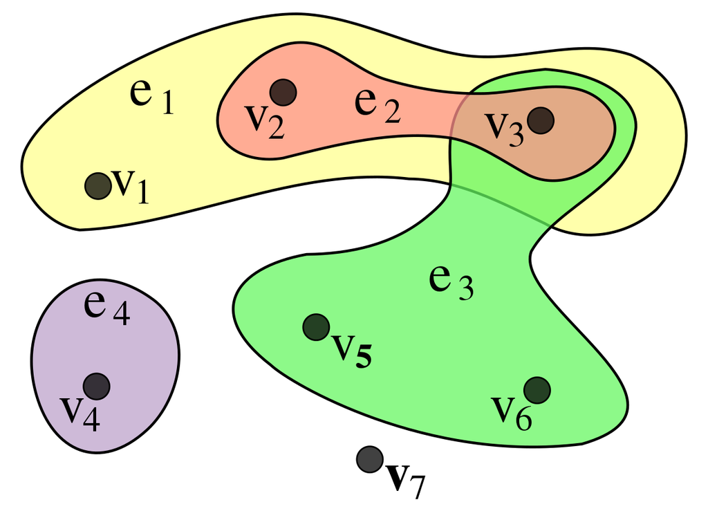

*Image: [Wikipedia](https://en.wikipedia.org/wiki/File:Hypergraph-wikipedia.svg)*

## Configuration Models for Hypergraphs

Observe $G$ with degree sequence $\mathrm{deg}(G) = \mathbf{d}\in \mathbb{R}^n$

**and edge dimension sequence** $\mathrm{dim}(G) = \mathbf{k} \in \mathbb{R}^m$.

Null space: all graphs with the same degree sequence

**and edge dimension sequence.**

The **vertex-labeled hypergraph configuration model** $\eta_{\mathbf{d}, \mathbf{k}}$ is the uniform distribution on this null space.

## Metropolis-Hastings Sampling

1. Initialize $G_0 \in \mathcal{V}_{\mathbf{d}, \mathbf{k}}$.
2. For $i = 0,1,2,\ldots$
- **Proposal:**
  - Select edges $\Delta$ and $\Gamma$ uniformly at random from $E_{i}$.
  - Randomly reshuffle nodes between $\Delta$ and $\Gamma$, preserving $\lvert \Delta \rvert$ and $\lvert \Gamma \rvert$.
- **Accept** the proposal with probability $a(\Delta, \Gamma) = \frac{1}{m_{\Delta}m_{\Gamma}}$, generating $G_{i+1}$.
3. Return $G_i$ at regular intervals of length $t$.

## Related Work (Read It!)

[figure not shown]

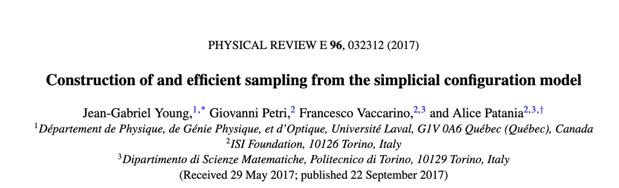

# Applications

## Thanks for the Data!

[figure not shown]

Time-stamped polyadic data sets: emails; drug co-occurrence; Congressional cosponsorships; academic coauthorships; forum threads…

# Assortativity in Polyadic Networks

## Hypergraph Assortativity

$$\rho_{\mathrm{polyadic}} = \frac{\langle r_ur_v \rangle - \langle r_u \rangle^2}{\langle r_u^2 \rangle - \langle r_u \rangle^2} = -0.25 \ll 0.99 = \rho_{\mathrm{dyadic}}$$

## Projected and Hypergraph Assortativities

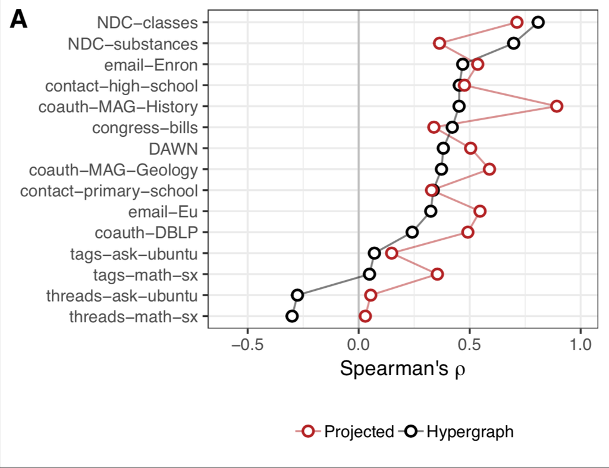

## Significance Tests

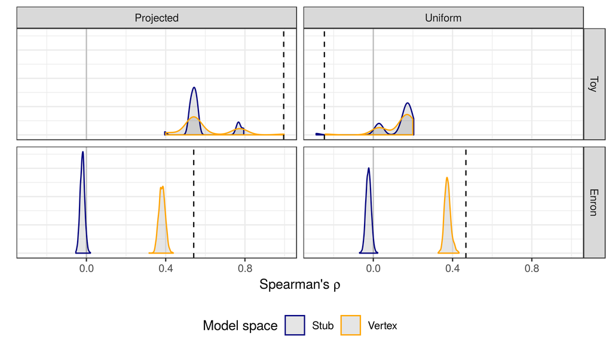

## Learnings

- Degree-assortativity can be studied **without projections**.
- Doing so **better matches our intuitions** about what assortativity “should mean” in many cases.
- The results can **vary significantly** from projected dyadic approaches.

# Revisiting Clustering

## The Global Clustering Coefficient

“Your friends tend to know each other…”

$$C = \frac{3 \times \text{Number of triangles}}{\text{Number of 2-stars}}$$

Recall (Strogatz and Watts 1998): Social networks display clustering; configuration models don’t; we need a small world model…

## Triadic Closure in Polyadic Networks

$$C = 3\times \frac{\binom{6}{3}}{3\times \binom{6}{3} + 1} \approx 0.98$$

- **“Trivial”** triadic closure from within edges.
- **“Nontrivial”** triadic closure from correlations between edges (Newman 2001).
- How to distinguish? Compare to a null distribution…

## Null Significance Tests

|  | $C$ | $\langle C \rangle_h$ | $\langle C \rangle_\text{dyadic}$ |
| --- | --- | --- | --- |
| **`congress-bills`** | **0.61** | 0.60 (0.00) | 0.45 (0.00) |
| `coauth-MAG-Geology` | 0.82 | 0.82 (0.00) | 0.00 (0.00) |
| *`email-Enron`* | *0.66* | 0.82 (0.01) | 0.64 (0.01) |
| *`email-Eu`* | *0.54* | 0.60 (0.01) | 0.40 (0.00) |
| *`tags-ask-ubuntu`* | *0.57* | 0.61 (0.01) | 0.19 (0.00) |
| *`threads-math-sx`* | *0.29* | 0.40 (0.01) | 0.04 (0.00) |

**Hypothesis:** When multi-way interactions are “cheap,” potential triangles get absorbed by polyadic edges. When coordination is required (e.g. collaborations), triangles may be more prevalent.

# Edge Intersection Profiles

## The Simplicial Clustering Hypothesis

**Hypothesis:** Edges have larger intersections than would be expected by random chance.

Related to *simplicial closure* hypothesis (Patania, Petri, and Vaccarino 2017; Benson et al. 2018).

## Intersection Profile

**Definition:** The *edge intersection profile* of a hypergraph is the empirical distribution

$$r(j) = \mathbb{P}(\left|\Delta \cap \Gamma\right| = j)\;,$$

where $\Delta$ and $\Gamma$ are uniformly random edges.

Large $r(j)$ $\implies$ intersections of size $j$ are common.

## Intersection Profile of Enron Emails

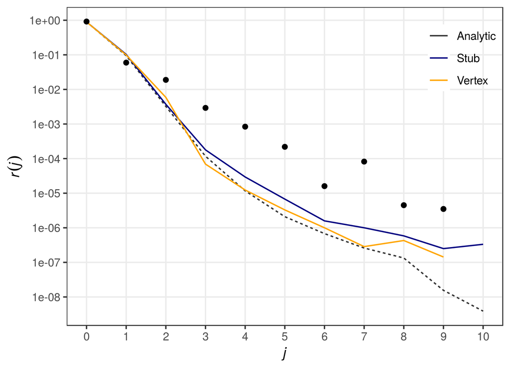

Large intersections much more common than expected under any null.

## Null Profiles for Large Networks

What if a network is too big for Monte Carlo sampling?

Let $r_{k\ell}(j) = \eta\left(\left|\Delta \cap \Gamma\right| = j|\left|\Delta\right| = k, \left|\Gamma\right| = \ell\right)$.

**Theorem**: When $\langle d^2 \rangle < \infty$,

$$r_{k\ell}(j) = (1 + O(n^{-1}))j!\binom{k}{j}\binom{\ell}{j}\left(\frac{1}{n} \frac{\langle d^2 \rangle - \langle d \rangle}{\langle d \rangle^2}\right)^j$$

with high probability as $n\rightarrow \infty$.

## Intersection Profiles for Large Networks

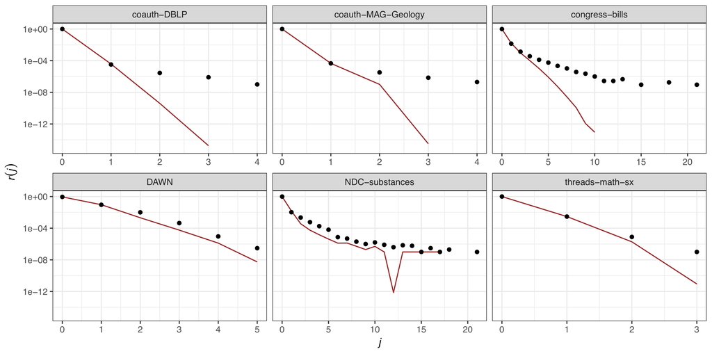

## Learnings

- Intersection profiles are **natively polyadic, scalable** measures of edge correlations.
- Some empirical networks are significantly clustered in this measure; others less so.

# Wrapping Up

## Takeaways

- Dyadic graph techniques can produce **unreliable results** on polyadic data sets.
- We should instead use natively polyadic **metrics** and **models**.
- Random hypergraph null models suggest **new perspectives** on some conventional wisdom in network science.

## Potential Future Directions

- Community detection in polyadic data sets
- Optimal projections (when you must…)
- Mean-field theory for hypergraph dynamics

## Thanks to…

- …**Patrick Jaillet** (MIT), for helpful discussions.
- …The **National Science Foundation**, for support under GRFP Grant 1122374.
- …**The organizers**, for the opportunity to present today.
- …To **you**, for your time and attention!

## Learn More

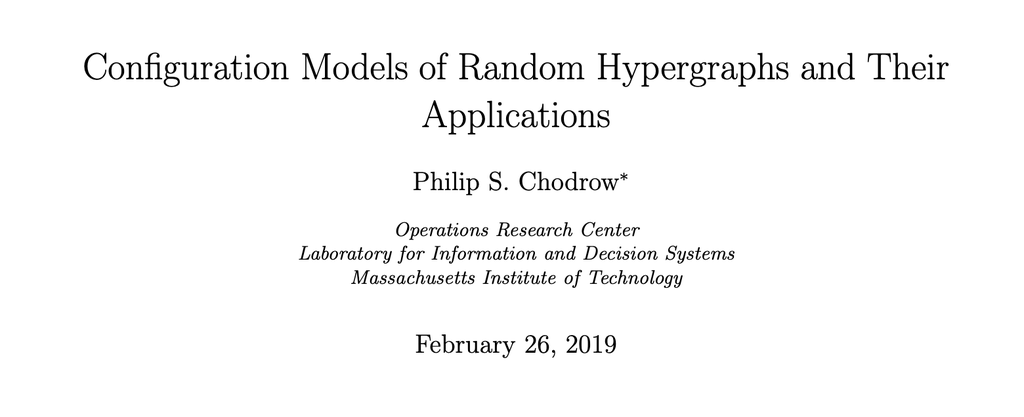

- **`arXiv`:** `1902.09302`
- **GitHub:** `PhilChodrow/hypergraph`
- `philchodrow.com`
- `@PhilChodrow`

## References

Benson, Austin R., Rediet Abebe, Michael T. Schaub, Ali Jadbabaie, and Jon Kleinberg. 2018. “Simplicial Closure and Higher-order Link Prediction.” *Proceedings of the National Academy of Sciences* 115 (48): 11221–30. http://arxiv.org/abs/1802.06916.

Newman, Mark E. J. 2001. “Scientific collaboration networks. I. Network construction and fundamental results.” *Physical Review E* 64 (1): 8. https://doi.org/10.1103/PhysRevE.64.016131.

Patania, Alice, Giovanni Petri, and Francesco Vaccarino. 2017. “The shape of collaborations.” *EPJ Data Science* 6 (1): 1–16. https://doi.org/10.1140/epjds/s13688-017-0114-8.

Strogatz, S. H., and D. J. Watts. 1998. “Collective dynamics of ’small-world’ networks.” *Nature* 393 (June): 440–42.